# tests-html

Shan Lu

2015年12月11日

# 各类检验

以下内容的数据集均为R自带数据集。 [R自带数据集的下载地址](https://vincentarelbundock.github.io/Rdatasets/datasets.html)

## 描述性统计

数据集mtcars描述：The data was extracted from the 1974 Motor Trend US magazine, and comprises fuel consumption and 10 aspects of automobile design and performance for 32 automobiles (1973–74 models).

### 载入数据

```r
setwd("/Users/shine/Documents/funcational\ data")
mtcars<-read.csv("mtcars.csv")
vars<-c("mpg","hp","wt")
head(mtcars[vars]) #只关注mtcars中的"mpg","hp","wt"这三个变量
```

```
##    mpg  hp    wt
## 1 21.0 110 2.620
## 2 21.0 110 2.875
## 3 22.8  93 2.320
## 4 21.4 110 3.215
## 5 18.7 175 3.440
## 6 18.1 105 3.460
```

### 计算描述性统计量

```r
##通过summary
summary(mtcars[vars])
```

```
##       mpg              hp              wt
##  Min.   :10.40   Min.   : 52.0   Min.   :1.513
##  1st Qu.:15.43   1st Qu.: 96.5   1st Qu.:2.581
##  Median :19.20   Median :123.0   Median :3.325
##  Mean   :20.09   Mean   :146.7   Mean   :3.217
##  3rd Qu.:22.80   3rd Qu.:180.0   3rd Qu.:3.610
##  Max.   :33.90   Max.   :335.0   Max.   :5.424
```

```r
##通过reshape包
library(reshape)
dstats<-function(x)(c(n=length(x), mean=mean(x), sd=sd(x)))#要计算观测值数量、均值、方差
dfm<-melt(mtcars, measure.vars=c("mpg", "hp", "wt"), id.vars=c("am","cyl"))
cast(dfm, am +cyl +variable ~ .,dstats)
```

```
##    am cyl variable  n       mean         sd
## 1   0   4      mpg  3  22.900000  1.4525839
## 2   0   4       hp  3  84.666667 19.6553640
## 3   0   4       wt  3   2.935000  0.4075230
## 4   0   6      mpg  4  19.125000  1.6317169
## 5   0   6       hp  4 115.250000  9.1787799
## 6   0   6       wt  4   3.388750  0.1162164
## 7   0   8      mpg 12  15.050000  2.7743959
## 8   0   8       hp 12 194.166667 33.3598379
## 9   0   8       wt 12   4.104083  0.7683069
## 10  1   4      mpg  8  28.075000  4.4838599
## 11  1   4       hp  8  81.875000 22.6554156
## 12  1   4       wt  8   2.042250  0.4093485
## 13  1   6      mpg  3  20.566667  0.7505553
## 14  1   6       hp  3 131.666667 37.5277675
## 15  1   6       wt  3   2.755000  0.1281601
## 16  1   8      mpg  2  15.400000  0.5656854
## 17  1   8       hp  2 299.500000 50.2045815
## 18  1   8       wt  2   3.370000  0.2828427
```

```r
#am/cyl是两个类别变量的名称
#id.var定义按照哪几个变量对原数据集拆分
#可以展示两个类别变量排列组合形成的各个子集合的描述性统计量，输出中每行是一个单独的子集，这里关注了均值、方差
```

### 频数表和列联表

数据集有5各变量，treatment表示服用药物或服用安慰剂，是类别变量；improved是病情是否有改善，有三类some/none/marked

```r
library(vcd)
head(Arthritis)##数据集来自vcd包
```

```
##   ID Treatment  Sex Age Improved
## 1 57   Treated Male  27     Some
## 2 46   Treated Male  29     None
## 3 77   Treated Male  30     None
## 4 17   Treated Male  32   Marked
## 5 36   Treated Male  46   Marked
## 6 23   Treated Male  58   Marked
```

#### 一维列联表，即频数表

目标：看病人的病情好转情况如何。

```r
##格式table(A, B),其中A是行变量，B是列变量
mytable<-with(Arthritis, table(Improved))
mytable
```

```
## Improved
##   None   Some Marked
##     42     14     28
```

```r
##用prop.table()将这些频数转化为比例值/prop.table()*100转化为百分比
prop.table(mytable)
```

```
## Improved
##      None      Some    Marked
## 0.5000000 0.1666667 0.3333333
```

```r
prop.table(mytable)*100
```

```
## Improved
##     None     Some   Marked
## 50.00000 16.66667 33.33333
```

无好转42人、一些好转14人，显著好转28人。

#### 二维列联表

目标：看服用安慰剂的病人中有多少人病情情况、服用药物的人中的病情情况。

```r
##xtabs(~A+B, data=mydata),AB是要进行交叉分类的变量；输出比table()语句多出了行、列的变量名称
mytable<-xtabs(~Treatment+ Improved, data= Arthritis)
mytable
```

```
##          Improved
## Treatment None Some Marked
##   Placebo   29    7      7
##   Treated   13    7     21
```

输出第一行第一列表示服用安慰剂的人中没有好转的病人有29人。

```r
#使用CrossTable生成二维列联表
library(gmodels)
CrossTable(Arthritis$Treatment, Arthritis$Improved)
```

```
##
##
##    Cell Contents
## |-------------------------|
## |                       N |
## | Chi-square contribution |
## |           N / Row Total |
## |           N / Col Total |
## |         N / Table Total |
## |-------------------------|
##
##
## Total Observations in Table:  84
##
##
##                     | Arthritis$Improved
## Arthritis$Treatment |      None |      Some |    Marked | Row Total |
## --------------------|-----------|-----------|-----------|-----------|
##             Placebo |        29 |         7 |         7 |        43 |
##                     |     2.616 |     0.004 |     3.752 |           |
##                     |     0.674 |     0.163 |     0.163 |     0.512 |
##                     |     0.690 |     0.500 |     0.250 |           |
##                     |     0.345 |     0.083 |     0.083 |           |
## --------------------|-----------|-----------|-----------|-----------|
##             Treated |        13 |         7 |        21 |        41 |
##                     |     2.744 |     0.004 |     3.935 |           |
##                     |     0.317 |     0.171 |     0.512 |     0.488 |
##                     |     0.310 |     0.500 |     0.750 |           |
##                     |     0.155 |     0.083 |     0.250 |           |
## --------------------|-----------|-----------|-----------|-----------|
##        Column Total |        42 |        14 |        28 |        84 |
##                     |     0.500 |     0.167 |     0.333 |           |
## --------------------|-----------|-----------|-----------|-----------|
##
##
```

展示了更丰富的信息,包括频数、频率。更多信息参考help(CrossTable)。

## 独立性检验

### 卡方独立性检验

“皮尔森卡方检定”可用于两种情境的变项比较：适配度检定，和独立性检定。 （1）“适配度检定”验证一组观察值的次数分配是否异于理论上的分配。 （2）“独立性检定”验证从两个变数抽出的配对观察值组是否互相独立（例如：每次都从A国和B国各抽一个人，看他们的反应是否与国籍无关）。 原假设是：一个样本中已发生事件的次数分配会遵守某个特定的理论分配。  
例子：想要知道治疗情况是否对改善情况有作用（换句话说，治疗情况和改善情况不独立）

```r
##R语句变成步骤：先生成列联表，再使用相应的检验方法
library(vcd)
mytable<-xtabs(~Treatment+ Improved, data= Arthritis)
chisq.test(mytable)##治疗情况和改善情况不独立
```

```
##
##  Pearson's Chi-squared test
##
## data:  mytable
## X-squared = 13.055, df = 2, p-value = 0.001463
```

```r
mytable<-xtabs(~Improved+ Sex, data=Arthritis)
chisq.test(mytable)##性别和改善情况独立
```

```
##
##  Pearson's Chi-squared test
##
## data:  mytable
## X-squared = 4.8407, df = 2, p-value = 0.08889
```

### cochran-mantel-haenszel检验

原假设：两个名义变量在第三个变量的每一层中都是条件独立的。 下面的代码可以检验治疗情况和改善情况在性别的每一水平下是否独立。此检验假设不存在三阶交互作用。

```r
mytable<-xtabs(~Treatment+ Improved+Sex,data=Arthritis)
mantelhaen.test(mytable)
```

```
##
##  Cochran-Mantel-Haenszel test
##
## data:  mytable
## Cochran-Mantel-Haenszel M^2 = 14.632, df = 2, p-value = 0.0006647
```

患者接受的治疗与得到的改善在性别的每一水平下并不独立，即分性别来看，用药治疗的患者较接受安慰剂的患者有了更多的改善

## t检验

最常用t检验的情况有： （1）单样本检验：检验一个正态分布的总体的均值是否在满足零假设的值之内，例如检验一群人的身高的平均是否符合170公分。 （2）双样本检验：其零假设为两个正态分布的总体的均值之差为某实数，例如检验二群人的身高之平均是否相等。这一检验通常被称为学生t检验。但更为严格地说，只有两个总体的方差是相等的情况下，才称为学生t检验；否则，有时被称为Welch检验。以上谈到的检验一般被称作“未配对”或“独立样本”t检验，我们特别是在两个被检验的样本没有重叠部分时用到这种检验方式。 （3）“配对”或者“重复测量”t检验：检验同一统计量的两次测量值之间的差异是否为零。举例来说，我们测量一位病人接受治疗前和治疗后的肿瘤尺寸大小。如果治疗是有效的，我们可以推定多数病人接受治疗后，肿瘤尺寸变小了。 （4）检验一条回归线的斜率是否显著不为零。

### 独立样本的t检验

数据集是MASS包中的美国犯罪率数据UScrime。 原假设：南方各州和非南方各州拥有相同的监禁概率

```r
library(MASS)
head(UScrime)#
```

```
##     M So  Ed Po1 Po2  LF  M.F Pop  NW  U1 U2 GDP Ineq     Prob    Time
## 1 151  1  91  58  56 510  950  33 301 108 41 394  261 0.084602 26.2011
## 2 143  0 113 103  95 583 1012  13 102  96 36 557  194 0.029599 25.2999
## 3 142  1  89  45  44 533  969  18 219  94 33 318  250 0.083401 24.3006
## 4 136  0 121 149 141 577  994 157  80 102 39 673  167 0.015801 29.9012
## 5 141  0 121 109 101 591  985  18  30  91 20 578  174 0.041399 21.2998
## 6 121  0 110 118 115 547  964  25  44  84 29 689  126 0.034201 20.9995
##      y
## 1  791
## 2 1635
## 3  578
## 4 1969
## 5 1234
## 6  682
```

```r
t.test(Prob~ So, data=UScrime)#假设方差不等的双侧检验
```

```
##
##  Welch Two Sample t-test
##
## data:  Prob by So
## t = -3.8954, df = 24.925, p-value = 0.0006506
## alternative hypothesis: true difference in means is not equal to 0
## 95 percent confidence interval:
##  -0.03852569 -0.01187439
## sample estimates:
## mean in group 0 mean in group 1
##      0.03851265      0.06371269
```

```r
##拒绝南方各州和非南方各州拥有相同监禁概率的假设
```

### 非独立样本的t检验

原假设：年长和年轻男性的平均失业率相同

```r
library(MASS)
sapply(UScrime[c("U1","U2")], function(x)(c(mean=mean(x),sd=sd(x))))
```

```
##            U1       U2
## mean 95.46809 33.97872
## sd   18.02878  8.44545
```

```r
with(UScrime, t.test(U1,U2,paired=TRUE))
```

```
##
##  Paired t-test
##
## data:  U1 and U2
## t = 32.407, df = 46, p-value < 2.2e-16
## alternative hypothesis: true difference in means is not equal to 0
## 95 percent confidence interval:
##  57.67003 65.30870
## sample estimates:
## mean of the differences
##                61.48936
```

拒绝年长和年轻男性的平均失业率相同的假设

## 方差分析

主要为探讨连续型的因变量与类别型自变量的关系，当自变量包含等于或超过三个类别情况下，检定其各类别间平均数是否相等。  
###单因素方差分析

```r
library(multcomp)
attach(cholesterol)
table(trt)#各组样本大小
```

```
## trt
##  1time 2times 4times  drugD  drugE
##     10     10     10     10     10
```

trt疗法（五个类别变量）和respose效果（连续型变量）。 原假设：五种疗法的治疗效果相同。

```r
aggregate(response, by=list(trt), FUN=mean)#先看一下各组均值，括号中依次是数据集、按哪个变量分组，计算什么.
```

```
##   Group.1        x
## 1   1time  5.78197
## 2  2times  9.22497
## 3  4times 12.37478
## 4   drugD 15.36117
## 5   drugE 20.94752
```

```r
aggregate(response, by=list(trt), FUN=sd)#再看各组方差
```

```
##   Group.1        x
## 1   1time 2.878113
## 2  2times 3.483054
## 3  4times 2.923119
## 4   drugD 3.454636
## 5   drugE 3.345003
```

```r
fit<- aov(response ~ trt)#用方差分析检验组间差异,aov(因变量 ~ 自变量)
summary(fit)#输出方差分析的结果
```

```
##             Df Sum Sq Mean Sq F value   Pr(>F)
## trt          4 1351.4   337.8   32.43 9.82e-13 ***
## Residuals   45  468.8    10.4
## ---
## Signif. codes:  0 '***' 0.001 '**' 0.01 '*' 0.05 '.' 0.1 ' ' 1
```

说明五种疗法的效果不同。  
可以绘制各组均值及其置信区间的图形。

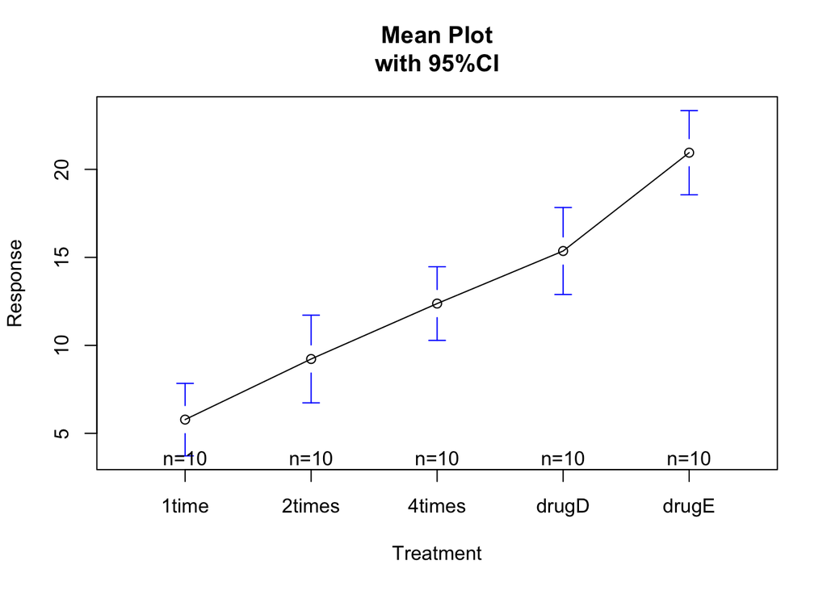

```r
library(gplots)
plotmeans(response ~ trt, xlab="Treatment", ylab="Response", main="Mean Plot\nwith 95%CI")
```

```r
detach(cholesterol)
```

如果数据无法满足t检验或ANOVA的参数假设，可以转而使用非参数方法。

## 以上参考网络资源及《R语言实战》。